# R Basic

2015-08-20

## Introduction

- 歡迎大家參加這次 DSC 2015 的 R Tutorial Workshop!
- 歡迎大家參加這次 DSC 2015 的 R Tutorial Workshop!
- 我們將會教導大家基本的資料分析技巧，包括資料整理 (ETL)、資料分析與資料視覺化等等。
- 歡迎大家參加這次 DSC 2015 的 R Tutorial Workshop!
- 我們將會教導大家基本的資料分析技巧，包括資料整理 (ETL)、資料分析與資料視覺化等等。
- 在這次的 workshop ，都是使用 `swirl` 這個 R 的互動式教學套件。
- 歡迎大家參加這次 DSC 2015 的 R Tutorial Workshop!
- 我們將會教導大家基本的資料分析技巧，包括資料整理 (ETL)、資料分析與資料視覺化等等。
- 在這次的 workshop ，都是使用 `swirl` 這個 R 的互動式教學套件。
- 跟 R 不熟? 跟 `swirl` 更不熟? 沒關係，我們會帶領大家一步一步使用 R 與 `swirl` 套件。
- 歡迎大家參加這次 DSC 2015 的 R Tutorial Workshop!
- 我們將會教導大家基本的資料分析技巧，包括資料整理 (ETL)、資料分析與資料視覺化等等。
- 在這次的 workshop ，都是使用 `swirl` 這個 R 的互動式教學套件。
- 跟 R 不熟? 跟 `swirl` 更不熟? 沒關係，我們會帶領大家一步一步使用 R 與 `swirl` 套件。
- OK! let the journey begin!

## Learn Swirl

- 還沒安裝 `DSC2015R` 的同學，請參考以下網址說明安裝:
  - [TaiwanRUser](https://github.com/TaiwanRUserGroup/DSC2015Tutorial#安裝課程所需套件)
- 還沒安裝 `DSC2015R` 的同學，請參考以下網址說明安裝:
  - [TaiwanRUser](https://github.com/TaiwanRUserGroup/DSC2015Tutorial#安裝課程所需套件)
  - 如果以上網址失效，請輸入下列指令安裝套件:

```r
options("DSC2015-repo" = "140.112.170.196")
source("http://140.112.170.196/R/init.R")
```

- 安裝完後，請輸入 `library("DSC2015R")`

```r
library("DSC2015R")
```

- 安裝完後，請輸入 `library("DSC2015R")`
- 為了避免課程內容版本有所出入，請先執行 `uninstall_all_courses()`。
- 安裝完後，請輸入 `library("DSC2015R")`
- 為了避免課程內容版本有所出入，請先執行 `uninstall_all_courses()`。
- 再執行 `install_course()` 安裝今日所需課程。

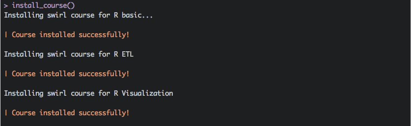

- 安裝完後，請輸入 `library("DSC2015R")`
- 為了避免課程內容版本有所出入，請先執行 `uninstall_all_courses()`。
- 再執行 `install_course()` 安裝今日所需課程。
- 最後執行 `packageVersion("DSC2015R")` 確認版本。

```r
packageVersion("DSC2015R")
```

```
## [1] '1.0'
```

- 執行 `swirl()` 進入互動教學模式。
- 執行 `swirl()` 進入互動教學模式。
- 遵照指令，你應該會看到:

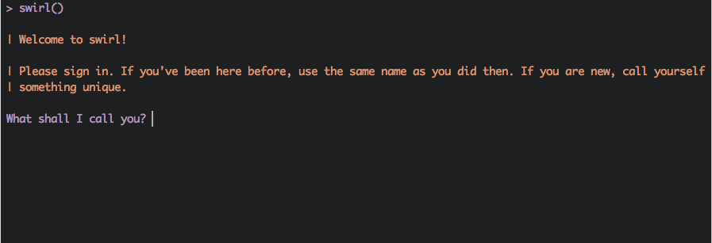

- 如果課程有安裝成功，你應該可以看到:

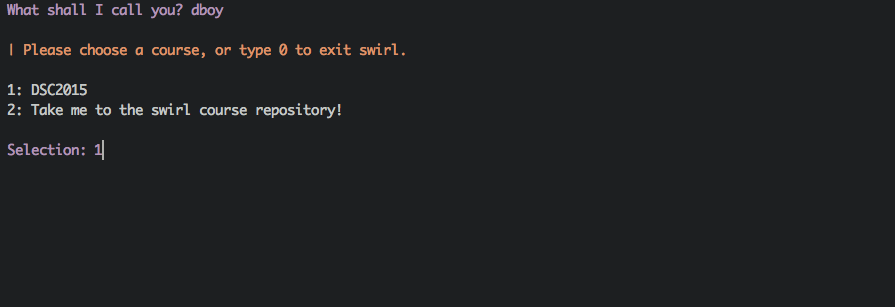

- 如果課程有安裝成功，你應該可以看到:

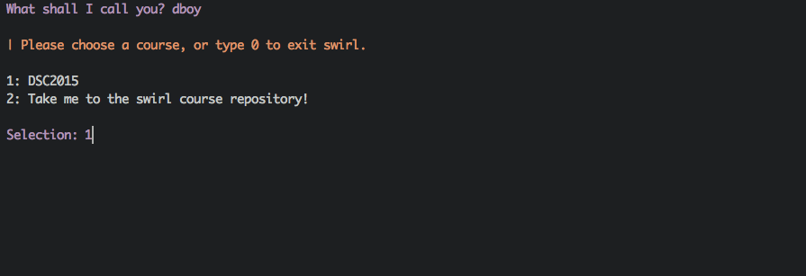

（如果這時候想跳出，可以輸入 0 。）

- 如果看到以下畫面，就成功進入 R Basic 互動課程選單!

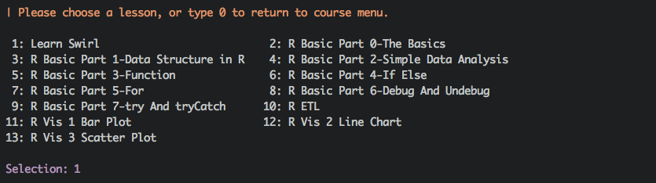

- 如果看到以下畫面，就成功進入 R Basic 互動課程選單!

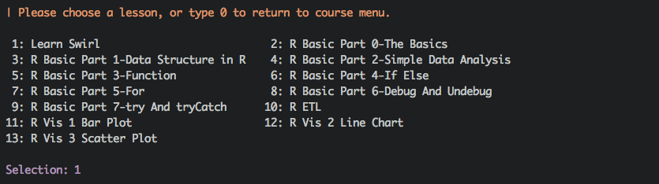

- 選取 `Learn Swirl` 一節開始吧!

## Before Move on Next Step

- 簡單總結一下剛剛學會的基本指令。
- 簡單總結一下剛剛學會的基本指令。
- `+`, `-`, `*`, `/` 可用於一般數值的加減乘除，須注意使用這些運算符於邏輯值的情況。
- 簡單總結一下剛剛學會的基本指令。
- `+`, `-`, `*`, `/` 可用於一般數值的加減乘除，須注意使用這些運算符於邏輯值的情況。
- `%%` 用於求餘數，`%/%` 用於求商。
- 簡單總結一下剛剛學會的基本指令。
- `+`, `-`, `*`, `/` 可用於一般數值的加減乘除，須注意使用這些運算符於邏輯值的情況。
- `%%` 用於求餘數，`%/%` 用於求商。
- `^` 用於計算冪級。
- 簡單總結一下剛剛學會的基本指令。
- `+`, `-`, `*`, `/` 可用於一般數值的加減乘除，須注意使用這些運算符於邏輯值的情況。
- `%%` 用於求餘數，`%/%` 用於求商。
- `^` 用於計算冪級。
- (Important!) 碰到問題可以用 `?` 與 `??` 查詢文件。

## Swirl Cheat Sheet

| 函數名 | 說明 |
| --- | --- |
| `info` | 列出 `swirl` 中可用的函式。 |
| `skip` | 跳至下一題。 |
| `play` | 暫時跳出 `swirl`。 |
| `nxt` | 跳回 `swirl`。 |
| `bye` | 結束 `swirl`。 |
| `main` | 跳至 `swirl` 主目錄區。 |

**Note**: 以上指令要在 `swirl` 中時看到 `>` 時才能使用。

## What's Next?

### Ning Chen

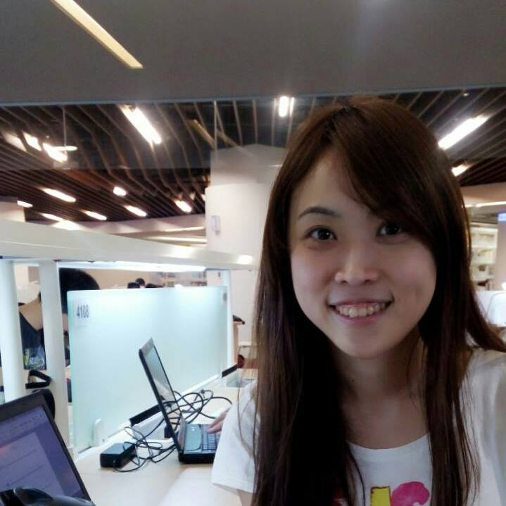

- Data Structure in R

### Ning Chen

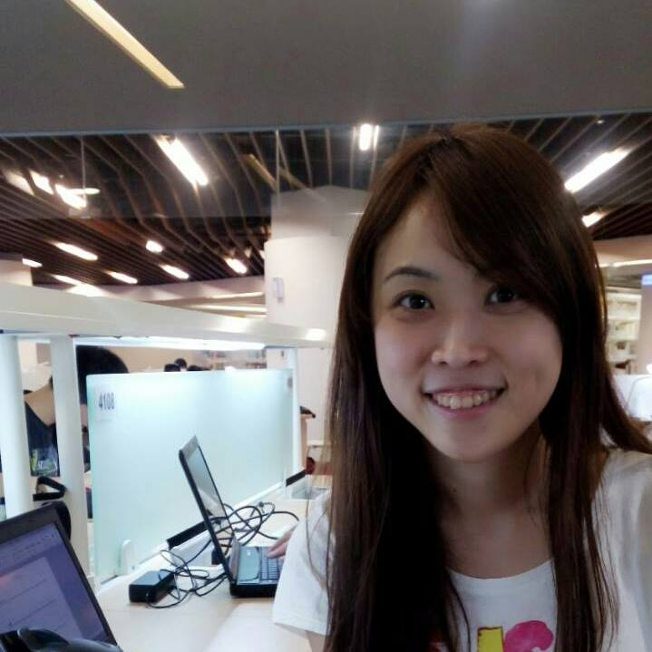

- Data Structure in R
- Basic Data Analysis with R

### Noah

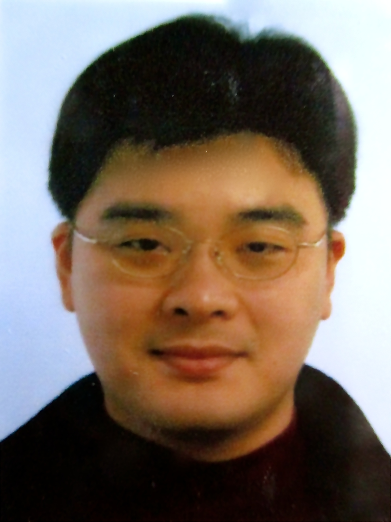

- User-Defined Function

### Noah

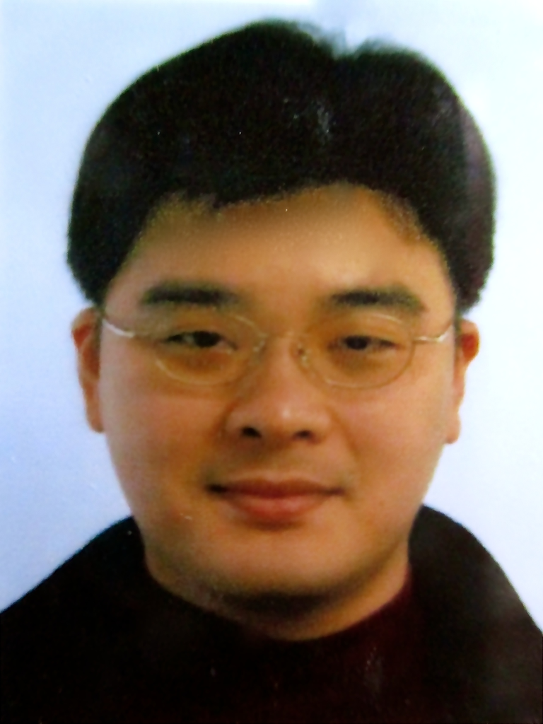

- User-Defined Function
- Control Flow and Exception Handling